# House Building with worker skills

This tutorial includes everything you need to set up Decision Optimization engines, build constraint programming models.

**Table of contents:**

- Describe the business problem
- How Decision Optimization can help
- Use Decision Optimization
  - Step 1: Set up the prescriptive engine
  - Step 2: Model the Data
  - Step 3: Set up the prescriptive model
    - Define the decision variables
    - Express the business constraints
    - Express the objective
    - Solve the model
  - Step 4: Investigate the solution and run an example analysis
- Summary

### Describe the business problem

- This is a problem of building five houses in different locations; the masonry, roofing, painting, etc. must be scheduled. Some tasks must necessarily take place before others and these requirements are expressed through precedence constraints.
- There are three workers, and each worker has a given skill level for each task. Each task requires one worker; the worker assigned must have a non-null skill level for the task. A worker can be assigned to only one task at a time.
- Each house has a deadline.
- The objective is to maximize the skill levels of the workers assigned to the tasks.

## How Decision Optimization can help

- Prescriptive analytics (Decision Optimization) technology recommends actions based on desired outcomes, taking into account specific scenarios, resources, and knowledge of past and current events. This insight can help your organization make better decisions and have greater control of business outcomes.
- Prescriptive analytics is the next step on the path to insight-based actions. It creates value through synergy with predictive analytics, which analyzes data to predict future outcomes.
- Prescriptive analytics takes that insight to the next level by suggesting the optimal way to handle that future situation. Organizations that can act fast in dynamic conditions and make superior decisions in uncertain environments gain a strong competitive advantage.
- For example:
  - Automate complex decisions and trade-offs to better manage limited resources.
  - Take advantage of a future opportunity or mitigate a future risk.
  - Proactively update recommendations based on changing events.
  - Meet operational goals, increase customer loyalty, prevent threats and fraud, and optimize business processes.

## About Detailed Scheduling concepts

- Scheduling consists of assigning start and completion times to a set of activities while satisfying different types of constraints (resource availability, precedence relationships, … ) and optimizing some criteria (minimizing tardiness, …)

[figure not shown]

- Time is considered as a continuous dimension: domain of possible start/completion times for an activity is potentially very large
- Besides start and completion times of activities, other types of decision variables are often involved in real industrial scheduling problems (resource allocation, optional activities …)

## Use Decision Optimization

### Step 1: Set up the prescriptive engine

For display of the solution, ensure that last version of matplotlib is available:

```python
try:
   import matplotlib
   if matplotlib.__version__ < "1.4.3":
        !pip install --upgrade matplotlib
except:
   !pip install --user matplotlib
```

Now, import all required modeling functions that are provided by the Constraint Programming *docplex.cp* package.

```python
from docplex.cp.model import CpoModel
from sys import stdout
from collections import namedtuple
```

### Step 2: Model the data

Planning contains the number of houses and the max amount of periods (*days*) for our schedule.

```python
NB_HOUSES = 5
MAX_AMOUNT_OF_PERIODS = 318
HOUSES = range(1, NB_HOUSES + 1)
```

All tasks must start and end between 0 and the max amount of periods.

```python
period_domain = (0, MAX_AMOUNT_OF_PERIODS)
```

For each task type in the house building project, the following table shows the duration of the task in days along with the tasks that must be finished before the task can start. A worker can only work on one task at a time; each task, once started, may not be interrupted.

| *Task* | *Duration* | *Preceding tasks* |
| --- | --- | --- |
| masonry | 35 |  |
| carpentry | 15 | masonry |
| plumbing | 40 | masonry |
| ceiling | 15 | masonry |
| roofing | 5 | carpentry |
| painting | 10 | ceiling |
| windows | 5 | roofing |
| facade | 10 | roofing, plumbing |
| garden | 5 | roofing, plumbing |
| moving | 5 | windows, facade, garden, painting |

##### Tasks' durations

```python
Task = (namedtuple("Task", ["name", "duration"]))
TASKS = {Task("masonry",   35),
         Task("carpentry", 15),
         Task("plumbing",  40),
         Task("ceiling",   15),
         Task("roofing",    5),
         Task("painting",  10),
         Task("windows",    5),
         Task("facade",    10),
         Task("garden",     5),
         Task("moving",     5)
        }
```

##### Task precedences

```python
TaskPrecedence = (namedtuple("TaskPrecedence", ["beforeTask", "afterTask"]))
TASK_PRECEDENCES = {TaskPrecedence("masonry",   "carpentry"),
                    TaskPrecedence("masonry",   "plumbing"),
                    TaskPrecedence("masonry",   "ceiling"),
                    TaskPrecedence("carpentry", "roofing"),
                    TaskPrecedence("ceiling",   "painting"),
                    TaskPrecedence("roofing",   "windows"),
                    TaskPrecedence("roofing",   "facade"),
                    TaskPrecedence("plumbing",  "facade"),
                    TaskPrecedence("roofing",   "garden"),
                    TaskPrecedence("plumbing",  "garden"),
                    TaskPrecedence("windows",   "moving"),
                    TaskPrecedence("facade",    "moving"),
                    TaskPrecedence("garden",    "moving"),
                    TaskPrecedence("painting",  "moving")
                   }
```

There are three workers with varying skill levels in regard to the ten tasks. If a worker has a skill level of zero for a task, he may not be assigned to the task.

| *Task* | *Joe* | *Jack* | *Jim* |
| --- | --- | --- | --- |
| masonry | 9 | 5 | 0 |
| carpentry | 7 | 0 | 5 |
| plumbing | 0 | 7 | 0 |
| ceiling | 5 | 8 | 0 |
| roofing | 6 | 7 | 0 |
| painting | 0 | 9 | 6 |
| windows | 8 | 0 | 5 |
| façade | 5 | 5 | 0 |
| garden | 5 | 5 | 9 |
| moving | 6 | 0 | 8 |

##### Workers Names

```python
WORKERS = {"Joe", "Jack", "Jim"}
```

##### Workers Name and level for each of there skill

```python
Skill = (namedtuple("Skill", ["worker", "task", "level"]))
SKILLS = {Skill("Joe",  "masonry",   9),
          Skill("Joe",  "carpentry", 7),
          Skill("Joe",  "ceiling",   5),
          Skill("Joe",  "roofing",   6),
          Skill("Joe",  "windows",   8),
          Skill("Joe",  "facade",    5),
          Skill("Joe",  "garden",    5),
          Skill("Joe",  "moving",    6),
          Skill("Jack", "masonry",   5),
          Skill("Jack", "plumbing",  7),
          Skill("Jack", "ceiling",   8),
          Skill("Jack", "roofing",   7),
          Skill("Jack", "painting",  9),
          Skill("Jack", "facade",    5),
          Skill("Jack", "garden",    5),
          Skill("Jim",  "carpentry", 5),
          Skill("Jim",  "painting",  6),
          Skill("Jim",  "windows",   5),
          Skill("Jim",  "garden",    9),
          Skill("Jim",  "moving",    8)
          }
```

##### Utility functions

find_tasks: returns the task it refers to in the TASKS vector

```python
def find_tasks(name):
    return next(t for t in TASKS if t.name == name)
```

find_skills: returns the skill it refers to in the SKILLS vector

```python
def find_skills(worker, task):
    return next(s for s in SKILLS if (s.worker == worker) and (s.task == task))
```

find_max_level_skill: returns the tuple "skill" where the level is themaximum for a given task

```python
def find_max_level_skill(task):
    st = [s for s in SKILLS if s.task == task]
    return next(sk for sk in st if sk.level == max([s.level for s in st]))
```

### Step 3: Set up the prescriptive model

### Create the model container

The model is represented by a Python object that is filled with the different model elements (variables, constraints, objective function, etc). The first thing to do is then to create such an object:

```python
mdl = CpoModel(name="HouseBuilding")
```

#### Define the decision variables

##### *Concept: interval variable*

- What for?

  > Modeling an interval of time during which a particular property holds  
  > (an activity executes, a resource is idle, a tank must be non-empty, …)
- Example:

  > `interval_var(start=(0,1000), end=(0,1000), size=(10,20))`

[figure not shown]

- Properties:
  - The **value** of an interval variable is an integer interval [start,end)
  - **Domain** of possible values: [0,10), [1,11), [2,12),...[990,1000), [0,11),[1,12),...
  - Domain of interval variables is represented **compactly** in CP Optimizer (a few bounds: smin, smax, emin, emax, szmin, szmax)

For each house, an interval variable is created for each task.  
This interval must start and end inside the period_domain and its duration is set as the value stated in TASKS definition.

```python
tasks = {}   # dict of interval variable for each house and task
for house in HOUSES:
    for task in TASKS:
        tasks[(house, task)] = mdl.interval_var(start=period_domain,
                                                end=period_domain,
                                                size=task.duration,
                                                name="house {} task {}".format(house, task))
```

##### *Concept: optional interval variable*

- Interval variables can be defined as being **optional** that is, it is part of the decisions of the problem to decide whether the interval will be **present** or **absent** in the solution
- What for?

  > Modeling optional activities, alternative execution modes for activities, and … most of the discrete decisions in a schedule
- Example:

  > `interval_var(optional=True, start=(0,1000), end=(0,1000), size=(10,20))`
- Properties:
  - An optional interval variable has an additional possible value in its domain (absence value)
  - **Optionality** is a powerful property that you must learn to leverage in your models

For each house, an **optional** interval variable is created for each skill.  
Skill being a tuple (worker, task, level), this means that for each house, an **optional** interval variable is created for each couple worker-task such that the skill level of this worker for this task is > 0.

The "**set_optional()**" specifier allows a choice between different variables, thus between different couples house-skill. This means that the engine decides if the interval will be present or absent in the solution.

```python
wtasks = {}  # dict of interval variable for each house and skill
for house in HOUSES:
    for skill in SKILLS:
        iv = mdl.interval_var(name='H' + str(house) + '-' + skill.task + '(' + skill.worker + ')')
        iv.set_optional()
        wtasks[(house, skill)] = iv
```

#### Express the business constraints

##### Temporal constraints

##### *Concept: precedence constraint*

- What for?
  - Modeling temporal constraints between interval variables
  - Modeling constant or variable minimal delays

Properties

> Semantic of the constraints handles optionality (as for all constraints in CP Optimizer).  
> Example of endBeforeStart:  
> `end_before_start(a,b,z)`  
> present(a) AND present(b) ⇒ end(a)+z ⩽ start(b)

The tasks in the model have precedence constraints that are added to the model.

```python
for h in HOUSES:
    for p in TASK_PRECEDENCES:
        mdl.add(mdl.end_before_start(tasks[(h, find_tasks(p.beforeTask))], tasks[(h, find_tasks(p.afterTask))]))
```

##### Alternative workers

##### *Concept: alternative constraint*

- What for?
  - Modeling alternative resource/modes/recipes
  - In general modeling a discrete selection in the schedule

Example:

> `alternative(a,[b1,...,bn])`

[figure not shown]

Remark: Master interval variable **a** can of course be optional

To constrain the solution so that exactly one of the interval variables wtasks associated with a given task of a given house is to be present in the solution, an "**alternative**" constraint is used.

```python
for h in HOUSES:
    for t in TASKS:
        mdl.add(mdl.alternative(tasks[(h, t)], [wtasks[(h, s)] for s in SKILLS if (s.task == t.name)], 1))
```

##### No overlap constraint

##### *Concept: No-overlap constraint*

- Constraint noOverlap schedules a group of interval variables in such a way that they do not overlap in time.
- Absent interval variables are ignored.
- It is possible to constrain minimum delays between intervals using transition matrix.
- It is possible to constraint the first, last in the sequence or next or preceding interval

[figure not shown]

To add the constraints that a given worker can be assigned only one task at a given moment in time, a **noOverlap** constraint is used.

```python
for w in WORKERS:
    mdl.add(mdl.no_overlap([wtasks[(h, s)] for h in HOUSES for s in SKILLS if s.worker == w]))
```

#### Express the objective

The presence of an interval variable in tasks in the solution must be accounted for in the objective. Thus for each of these possible tasks, the cost is incremented by the product of the skill level and the expression representing the presence of the interval variable in the solution.

The objective of this problem is to maximize the skill level used for all the tasks.

```python
obj = mdl.sum([s.level * mdl.presence_of(wtasks[(h, s)]) for s in SKILLS for h in HOUSES])
mdl.add(mdl.maximize(obj))
```

#### Solve the model

The model is now completely defined. It is time to solve it !

```python
# Solve the model
print("\nSolving model....")
msol = mdl.solve(TimeLimit=10)
```

```
Solving model....
 ! --------------------------------------------------- CP Optimizer 22.1.1.0 --
 ! Maximization problem - 153 variables, 123 constraints
 ! TimeLimit            = 10
 ! Initial process time : 0.02s (0.02s extraction + 0.00s propagation)
 !  . Log search space  : 330.1 (before), 330.1 (after)
 !  . Memory usage      : 894.1 kB (before), 894.1 kB (after)
 ! Using parallel search with 32 workers.
 ! ----------------------------------------------------------------------------
 !          Best Branches  Non-fixed    W       Branch decision
                        0        153                 -
 + New bound is 385
 ! Using iterative diving.
 ! Using temporal relaxation.
                        0        153    1            -
```

[output cut: 599 more lines]

### Step 4: Investigate the solution and run an example analysis

```python
print("Solve status: " + msol.get_solve_status())
if msol.is_solution():
    stdout.write("Solve time: " + str(msol.get_solve_time()) + "\n")
    # Sort tasks in increasing begin order
    ltasks = []
    for hs in HOUSES:
        for tsk in TASKS:
            (beg, end, dur) = msol[tasks[(hs, tsk)]]
            ltasks.append((hs, tsk, beg, end, dur))
    ltasks = sorted(ltasks, key = lambda x : x[2])
    # Print solution
    print("\nList of tasks in increasing start order:")
    for tsk in ltasks:
        print("From " + str(tsk[2]) + " to " + str(tsk[3]) + ", " + tsk[1].name + " in house " + str(tsk[0]))
else:
    stdout.write("No solution found\n")
```

```
Solve status: Feasible
Solve time: 10.16

List of tasks in increasing start order:
From 0 to 35, masonry in house 2
From 0 to 35, masonry in house 4
From 35 to 50, ceiling in house 2
From 35 to 70, masonry in house 5
From 50 to 60, painting in house 2
From 50 to 65, ceiling in house 4
From 65 to 75, painting in house 4
From 65 to 105, plumbing in house 4
From 70 to 105, masonry in house 1
From 75 to 90, carpentry in house 5
From 105 to 140, masonry in house 3
From 105 to 120, ceiling in house 5
From 120 to 130, painting in house 5
From 120 to 160, plumbing in house 5
From 140 to 155, carpentry in house 2
From 155 to 170, carpentry in house 4
From 160 to 200, plumbing in house 3
From 170 to 185, ceiling in house 3
From 185 to 200, ceiling in house 1
From 185 to 195, painting in house 3
From 200 to 240, plumbing in house 2
From 200 to 215, carpentry in house 3
From 215 to 230, carpentry in house 1
From 230 to 235, roofing in house 5
From 235 to 240, windows in house 5
From 235 to 240, garden in house 5
From 240 to 245, roofing in house 3
From 240 to 250, facade in house 5
From 245 to 250, garden in house 3
From 245 to 250, roofing in house 4
From 250 to 255, roofing in house 2
From 250 to 255, windows in house 3
From 250 to 255, garden in house 4
From 255 to 260, roofing in house 1
From 255 to 260, garden in house 2
From 255 to 260, windows in house 4
From 260 to 265, windows in house 1
From 260 to 300, plumbing in house 1
From 260 to 265, moving in house 5
From 265 to 275, facade in house 2
From 275 to 285, facade in house 4
From 285 to 295, facade in house 3
From 285 to 290, moving in house 4
From 298 to 303, windows in house 2
From 298 to 303, moving in house 3
From 300 to 310, painting in house 1
From 303 to 313, facade in house 1
From 303 to 308, moving in house 2
From 308 to 313, garden in house 1
From 313 to 318, moving in house 1
```

#### Import graphical tools

*You can set **POP_UP_GRAPHIC=True** if you prefer a pop up graphic window instead of an inline one.*

```python
POP_UP_GRAPHIC=False
```

```python
import docplex.cp.utils_visu as visu
import matplotlib.pyplot as plt
if not POP_UP_GRAPHIC:
    %matplotlib inline
#Change the plot size
from pylab import rcParams
rcParams['figure.figsize'] = 15, 3
```

#### Draw solution

#### Useful functions

To facilitate the display of tasks names, keep only the first n characters.

```python
def compact_name(name,n): return name[:n]
```

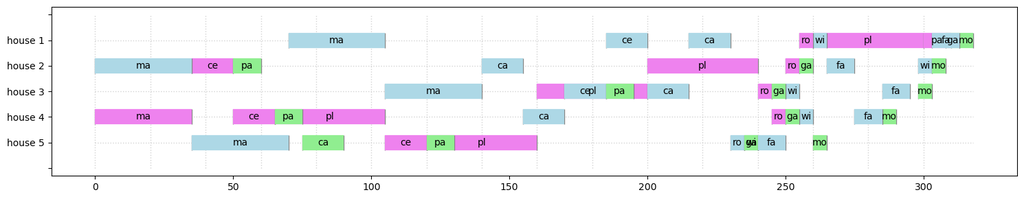

```python
if msol and visu.is_visu_enabled():
    workers_colors = {}
    workers_colors["Joe"] = 'lightblue'
    workers_colors["Jack"] = 'violet'
    workers_colors["Jim"] = 'lightgreen'
    visu.timeline('Solution per houses', 0, MAX_AMOUNT_OF_PERIODS)
    for h in HOUSES:
        visu.sequence(name="house " + str(h))
        for s in SKILLS:
            wt = msol.get_var_solution(wtasks[(h,s)])
            if wt.is_present():
                color = workers_colors[s.worker]
                wtname = compact_name(s.task,2)
                visu.interval(wt, color, wtname)
    visu.show()
```

The purpose of this function is to compact the names of the different tasks to make the graphical display more readable.

For example "H3-garden" becomes "G3"

```python
def compact_house_task(name):
    loc, task = name[1:].split('-', 1)
    return task[0].upper() + loc
```

A green color is used in the display when the task is using the most skilled worker. A red color is used in the display when the task does not use the most skilled worker.

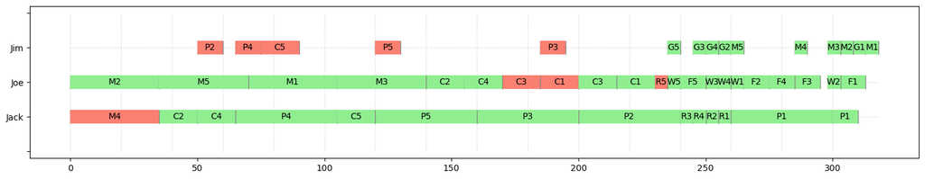

```python
if msol and visu.is_visu_enabled():
    visu.timeline('Solution per workers', 0, MAX_AMOUNT_OF_PERIODS)
    for w in WORKERS:
        visu.sequence(name=w)
        for h in HOUSES:
            for s in SKILLS:
                if s.worker == w:
                    wt = msol.get_var_solution(wtasks[(h,s)])
                    if wt.is_present():
                        ml = find_max_level_skill(s.task).level
                        if s.level == ml:
                            color = 'lightgreen'
                        else:
                            color = 'salmon'
                        wtname = compact_house_task(wt.get_name())
                        visu.interval(wt, color, wtname)
    visu.show()
```

#### Going further with Constraint Programming

The last available installable package is available on Pypi here: https://pypi.python.org/pypi/docplex

A complete set of modeling examples can be downloaded here: https://github.com/IBMDecisionOptimization/docplex-examples

## Summary

You have learned how to set up and use the IBM Decision Optimization CPLEX Modeling for Python to build and solve a Constraint Programming model.

#### References

- [Decision Optimization CPLEX Modeling for Python documentation](https://rawgit.com/IBMDecisionOptimization/docplex-doc/master/docs/index.html)
- [IBM Cloud Pak for Data as a Service documentation](https://dataplatform.cloud.ibm.com/docs/content/wsj/getting-started/welcome-main.html?context=cpdaas)
- [IBM watsonx.ai documentation](https://dataplatform.cloud.ibm.com/docs/content/wsj/getting-started/welcome-main.html?context=wx)

Copyright © 2017-2025. This notebook and its source code are released under the terms of the MIT License.